# Lab 07 - Data Visualization - Andrew Badzioch

# Lab07: Part 1

### What is Data Visualization (Viz)

- data visualization is the graphical presentation of the data

#### Uses of Data Visualization:

1. It makes it easier and faster for a data analyst (data scientist) to discover the data patterns.
2. To find out about the current trends in the dataset.
3. To make more effective team communication.
4. To offer a better understanding of data to the non-technical people such as the management team and to enable them to make more informed decisions.

#### Python Libraries for Data Visualization:

1. matplotlib
2. seaborn
- both of these libraries are built ontop of NumPy
- these libraries are said to be platform-independant:
  - they can operate on different OSs such as Windows, Linux, and MacOS
- Python pyplot is an API that enables matplotlib to perform more effectively and interactively
- the best source for matplotlib is: https://matplotlib.org/

```python
# installing matplotlib
# !pip install matplotlib
```

```python
import matplotlib
```

```python
# importing visualization libraries
import matplotlib.pyplot as plt # plt is an alias name for pyplot
import seaborn as sns # sns is an alias for seaborn

# import numpy as np
# import pandas as pd
```

```python
# checking the version of matplotlib
print(matplotlib.__version__)
```

```
3.8.3
```

```python
# checking the version of seaborn
print(sns.__version__)
```

```
0.13.2
```

### Importing Libraries

```python
# general libraries
import numpy as np
import pandas as pd
import os
import math

# data visualization libraries
import matplotlib.pyplot as plt
import seaborn as sns

# suppressing warnings
import warnings
warnings.filterwarnings('ignore')
```

## Part 1: Types of Graphs and Plots

#### 1. Line Plots

- one of the simplest plots
- they indicate the progress of a trend over time

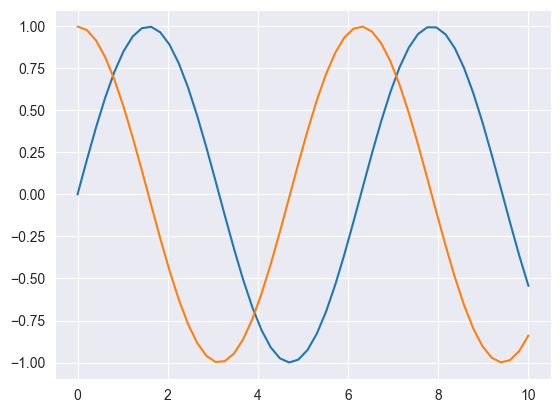

```python
# let's create the dataset
a = np.linspace(0, 10)

# creating the line plot with matplotlib.pyplot
plt.plot(a, np.sin(a))
plt.plot(a, np.cos(a))
```

**Observations:**

- add semi colon (;) at end of last line to get rid off excess data (under the hood)
- call most plots by using plt.PLOTNAME from pyplot

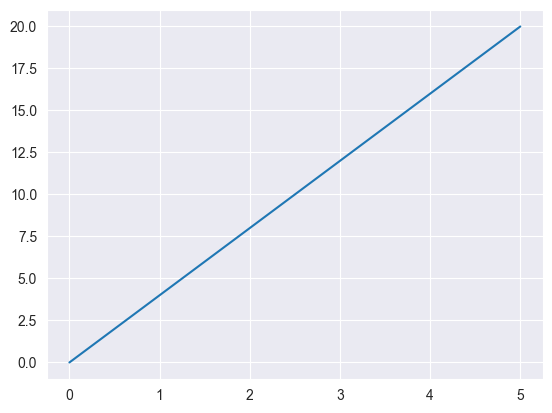

```python
# creating the dataset
x = np.array([0, 5])
y = np.array([0, 20])

# creating the plot
plt.plot(x, y)
```

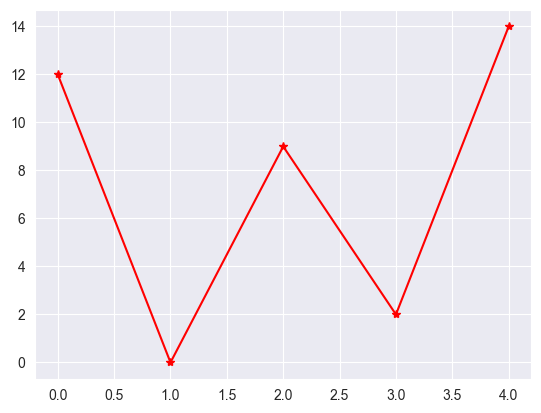

```python
# creating the dataset
y = np.array([12,0,9,2,14])

# creating the plot
plt.plot(y, color='red', marker='*')
```

**Observations:not really needed**

- blue is the default color

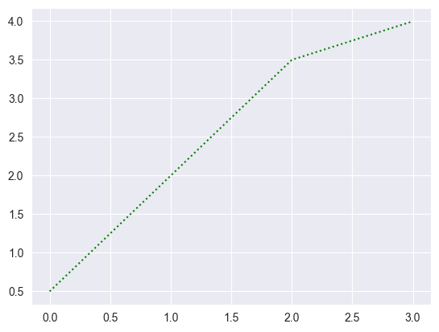

```python
# creating the dataset
y = np.array([0.5, 2.0, 3.5, 4.0])

# creating the plot
plt.plot(y, color='green', linestyle='dotted') # we can have 'dashed' as the line style as well
```

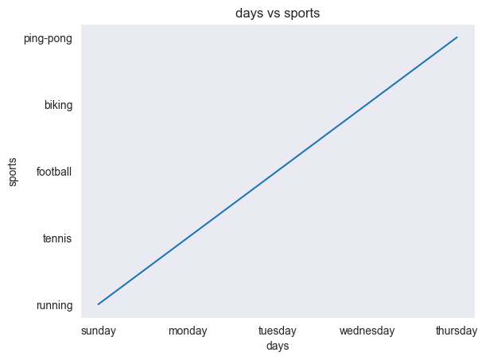

```python
# creating the dataset
x = pd.Series(['sunday', 'monday', 'tuesday', 'wednesday', 'thursday'])
y = pd.Series(['running', 'tennis', 'football', 'biking', 'ping-pong'])

# creating the plot
plt.plot(x, y)

# adding more items to the plot
plt.title('days vs sports') # adding a title to the graph
plt.xlabel('days') # adding x label
plt.ylabel('sports') # adding y label

# adding a grid
plt.grid()
```

#### 2. Bar Plots

- bar plots are used to compare different categories

```
<BarContainer object of 4 artists>
```

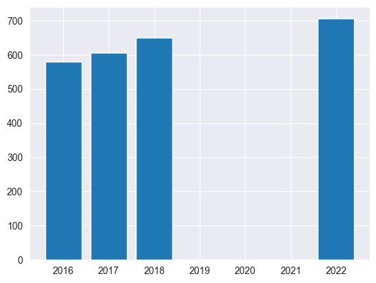

```python
# creating the dataset
df1 = pd.DataFrame.from_dict(
    {'year': [2016, 2017, 2018, 2022],
     'men': [300, 305, 325, 350],
     'women': [280, 301, 325, 355],
     'total': [580, 606, 650, 705]
     }
)

# creating the bar plot
plt.bar(x=df1['year'], height=df1['total'])
```

#### 3. Pie Charts

- pie charts are used to indicate the proportion over the whole

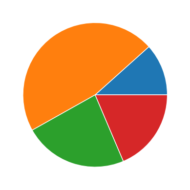

```python
# creating the dataset
y = np.array([5, 20, 10, 8])

# creating the plot
plt.pie(y);
```

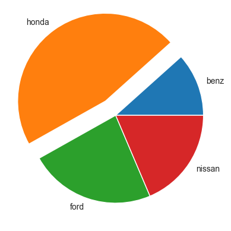

```python
# creating the dataset
y = np.array([5, 20, 10, 8])

# adding labels
cars = ['benz', 'honda', 'ford', 'nissan']

# making the wedges stand out
wedge = [0, 0.2, 0, 0]

# creating the plot
plt.pie(y, labels=cars, explode=wedge);
```

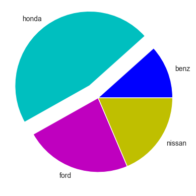

```python
# creating the dataset
y = np.array([5, 20, 10, 8])

# adding labels
cars = ['benz', 'honda', 'ford', 'nissan']

# making the wedges stand out
wedge = [0, 0.2, 0, 0]

# new colors
colrs = ['b', 'c', 'm', 'y']

# creating the plot
plt.pie(y, labels=cars, explode=wedge, colors=colrs);
```

##### Color Codes:

1. 'r' for red
2. 'g' for green
3. 'b' for blue
4. 'c' for cyan
5. 'm' for magenta
6. 'y' for yellow
7. 'k' for black
8. 'w' for white

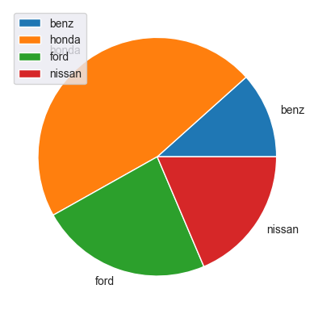

```python
# creating the dataset
y = np.array([5, 20, 10, 8])

# adding labels
cars = ['benz', 'honda', 'ford', 'nissan']

# creating the plot
plt.pie(y, labels=cars)

# adding a legend
plt.legend()
```

#### 4. Scatter Plots

- scatter plots are used to find the relationship between different variables
- each dot shows one observation (row)
- the two variables should be of the same size (the same number of rows)

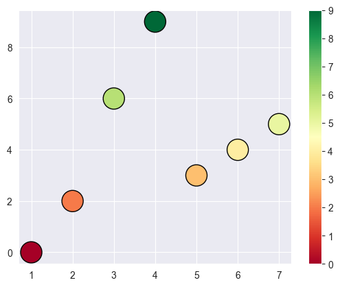

```python
# creating the dataset
x = np.array([1,2,3,4,5,6,7])
y = np.array([0,2,6,9,3,4,5])

# creating the plot
plt.scatter(x, y, c=y, cmap='RdYlGn', s=500, edgecolors='black')
plt.colorbar()
```

**Observations:**

- create the scatter plot with x and y
- c=y colors the points based on their y values
- cmap: the colormap used will be set to 'Red-Yellow-Green'
- s: dot (marker) size
- edgecolor: the color around the dots (markers)
- plt.colorbar: adds the color bar to the plot, helping to interpret the mapping of data values to the colors

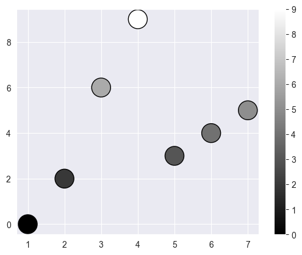

```python
# creating the dataset
x = np.array([1,2,3,4,5,6,7])
y = np.array([0,2,6,9,3,4,5])

# creating the plot
plt.scatter(x, y, c=y, cmap='RdYlGn', s=500, edgecolors='black')
plt.colorbar()
plt.gray() # makes everything gray scale
```

#### 5. Histogram

- one of the most popular plots
- used to find the data distribution (frequency)
- the two variables should be of the same size (the same number of rows)

**Types of Distribution:**

1. Normal (zero skewness)
2. Right-Skewed
3. Left-Skewed

#### 6. Heatmaps

- used to find out about the correlation between various variables

### Conclusion:

- Matplotlib allows customization of plots, including adjusting colors, markers, lines, label, and tick marks
- it provides many types of visualizations (line graphs, bar charts, scatter plots, pie charts, histograms, and heatmaps)
- line charts are one of the most commonly used plots in Matplotlib, ideal for trends over time
- line charts allow plotting multiple lines on the same axes
- bar charts are great for comparing discrete or categorical data
- pie charts are used for visualizing the parts of a whole and showing percentage distributions
- pie charts allow for "exploding" slices to emphasize specific selections
- scatter plots are best for visualizing relationships or correlations betwwen 2 continuous variables
- Matplotlib allows for extensive customization of marker size (s), colors (c), and shapes based on additional data
- histograms are ideal for visualizing the distibution of a single continuous variable
- heatmaps are useful for visualizing data intensity across a 2D matrix

##### End of Lab 07 Part 1

# Lab 07: Part 2

### DS Steps:

1. Introduction:
   - Background (context): in this project, we use the titanic dataset.
   - Objectives: we want to perform data visualization
   - **Data Description:**
     - PassengerId: unique identifier for each passenger
     - Survived: survived = (1), did not survive (0)
     - Pclass: class of ticket purchased (1= first class, 2= second class, 3= third class)
     - Name: full name of the passenger
     - Sex: the gender of the passenger (male or female)
     - Age: age of the passenger in years
     - SibSp: number of siblings or spouses the passenger had aboard
     - Parch: number of parents or children the passenger had aboard
     - Ticket: ticket number for the passenger
     - Fare: amount paid for the ticket
     - Cabin: cabin number where the passenger stayed
     - Embarked: port where the passenger boarded (C= Cherbourg, Q= Queenstown, S= Southampton)
2. Importing libraries
3. Loading the dataset
4. Performing EDA
5. Data Visualization
6. Data Mining
7. Data Presentation

```python
# step 2. importing libraries

# general libraries
import numpy as np
import pandas as pd
import math

# data visualization libraries
import matplotlib.pyplot as plt
import seaborn as sns

# libraries for suppressing the warnings
import warnings
warnings.filterwarnings('ignore')
```

```python
# step 3. loading the dataset
df = pd.read_csv('titanic.csv')
```

```python
# making a copy
titanic = df.copy()
```

```python
# making sure the dataset has been loaded
titanic.head()
```

|  | PassengerId | Survived | Pclass | Name | Sex | Age | SibSp | Parch | Ticket | Fare | Cabin | Embarked |
| --- | --- | --- | --- | --- | --- | --- | --- | --- | --- | --- | --- | --- |
| 0 | 1 | 0 | 3 | Braund, Mr. Owen Harris | male | 22.0 | 1 | 0 | A/5 21171 | 7.2500 | NaN | S |
| 1 | 2 | 1 | 1 | Cumings, Mrs. John Bradley (Florence Briggs Th... | female | 38.0 | 1 | 0 | PC 17599 | 71.2833 | C85 | C |
| 2 | 3 | 1 | 3 | Heikkinen, Miss. Laina | female | 26.0 | 0 | 0 | STON/O2. 3101282 | 7.9250 | NaN | S |
| 3 | 4 | 1 | 1 | Futrelle, Mrs. Jacques Heath (Lily May Peel) | female | 35.0 | 1 | 0 | 113803 | 53.1000 | C123 | S |
| 4 | 5 | 0 | 3 | Allen, Mr. William Henry | male | 35.0 | 0 | 0 | 373450 | 8.0500 | NaN | S |

**Observations:**

#### variables = (columns) = (features)

1. categorical = (categories) = (classes)
   - nominal (names)
   - ordinal (ordered)
2. numeric
   - continuous (temperature)
   - discrete (age)

```python
# step 4. EDA
# attributes
titanic.shape
```

```
(891, 12)
```

**Observations:**

- dataset has 891 rows
- dataset has 12 columns (features)

```python
titanic.size
```

```
10692
```

**Observations:**

- size is rows * columns
- total size of this dataset is 10692

```python
titanic.dtypes
```

```
PassengerId      int64
Survived         int64
Pclass           int64
Name            object
Sex             object
Age            float64
SibSp            int64
Parch            int64
Ticket          object
Fare           float64
Cabin           object
Embarked        object
dtype: object
```

**Observations:**

- total dataset is a mixture of integers, floats, and objects

```python
titanic.columns
```

```
Index(['PassengerId', 'Survived', 'Pclass', 'Name', 'Sex', 'Age', 'SibSp',
       'Parch', 'Ticket', 'Fare', 'Cabin', 'Embarked'],
      dtype='object')
```

```python
titanic.ndim
```

```
2
```

```python
# let's get more information about the dataset
titanic.info()
```

```
<class 'pandas.core.frame.DataFrame'>
RangeIndex: 891 entries, 0 to 890
Data columns (total 12 columns):
 #   Column       Non-Null Count  Dtype
---  ------       --------------  -----
 0   PassengerId  891 non-null    int64
 1   Survived     891 non-null    int64
 2   Pclass       891 non-null    int64
 3   Name         891 non-null    object
 4   Sex          891 non-null    object
 5   Age          714 non-null    float64
 6   SibSp        891 non-null    int64
 7   Parch        891 non-null    int64
 8   Ticket       891 non-null    object
 9   Fare         891 non-null    float64
 10  Cabin        204 non-null    object
 11  Embarked     889 non-null    object
dtypes: float64(2), int64(5), object(5)
memory usage: 83.7+ KB
```

**Observations:**

- class: the main information about the dataframe is
- RangeIndex: gives the total number of entries and the index range
- Data columns: the total number of columns along with their name, count, if there are any empty places, and data type
- dtype: the type of data for every column (object=mixed values), (int64=integer)

```python
# let's get the statistical summary
titanic.describe()
```

|  | PassengerId | Survived | Pclass | Age | SibSp | Parch | Fare |
| --- | --- | --- | --- | --- | --- | --- | --- |
| count | 891.000000 | 891.000000 | 891.000000 | 714.000000 | 891.000000 | 891.000000 | 891.000000 |
| mean | 446.000000 | 0.383838 | 2.308642 | 29.699118 | 0.523008 | 0.381594 | 32.204208 |
| std | 257.353842 | 0.486592 | 0.836071 | 14.526497 | 1.102743 | 0.806057 | 49.693429 |
| min | 1.000000 | 0.000000 | 1.000000 | 0.420000 | 0.000000 | 0.000000 | 0.000000 |
| 25% | 223.500000 | 0.000000 | 2.000000 | 20.125000 | 0.000000 | 0.000000 | 7.910400 |
| 50% | 446.000000 | 0.000000 | 3.000000 | 28.000000 | 0.000000 | 0.000000 | 14.454200 |
| 75% | 668.500000 | 1.000000 | 3.000000 | 38.000000 | 1.000000 | 0.000000 | 31.000000 |
| max | 891.000000 | 1.000000 | 3.000000 | 80.000000 | 8.000000 | 6.000000 | 512.329200 |

**Observations:**

- statistical summary for each numerical columns in the DataFrame
- by default, it will exclude non_numerical data
- allows for a quick understanding of the distribution and spread of the data
- excludes missing values when returning the summary statistics
- can be customized to control which data types to include by passing 'all' or 'object'

```python
# let's get the summary of the object dtypes in the dataset
titanic.describe(include='object')
```

|  | Name | Sex | Ticket | Cabin | Embarked |
| --- | --- | --- | --- | --- | --- |
| count | 891 | 891 | 891 | 204 | 889 |
| unique | 891 | 2 | 681 | 147 | 3 |
| top | Braund, Mr. Owen Harris | male | 347082 | B96 B98 | S |
| freq | 1 | 577 | 7 | 4 | 644 |

**Observations:**

- return the categorical data with 'object'
- can be used with 'all' as well

```python
titanic.isnull().sum()
```

```
PassengerId      0
Survived         0
Pclass           0
Name             0
Sex              0
Age            177
SibSp            0
Parch            0
Ticket           0
Fare             0
Cabin          687
Embarked         2
dtype: int64
```

**Observations:**

- .isnull() will return the Boolean (True/False) of all entries in dataset
- .sum() returns the count for the Boolean vaules making it easier to understand

#### Univariate

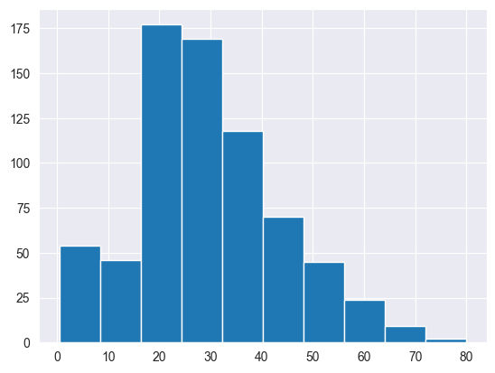

```python
# step 5. Data Visualization

# let's see the data distribution in the age variable
plt.hist(titanic['Age']);
```

**Observations:**

- histograms provide a visual representation of the distribution shape of the dataset
- each bar represents the frequency (count) of data points within the specific range

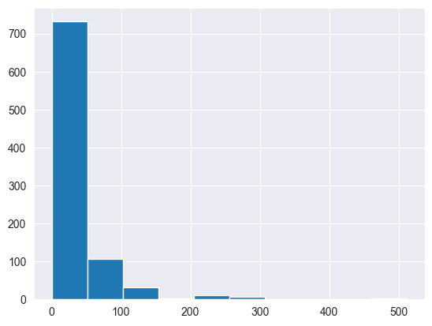

```python
plt.hist(titanic['Fare']);
```

**Observations:**

- the majority of passengers paid between 0 and 50
- there are a few people that paid more than 100

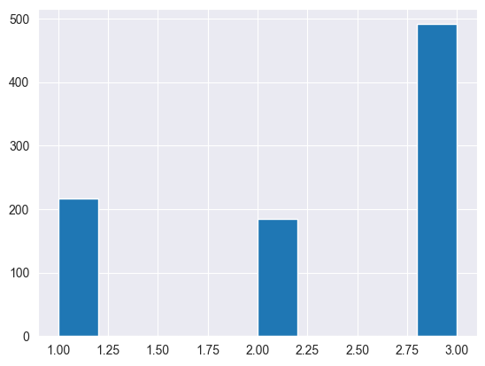

```python
plt.hist(titanic['Pclass'])
```

```python
# Let's see the data distribution for sex variable
titanic['Sex'].value_counts()
```

```
Sex
male      577
female    314
Name: count, dtype: int64
```

**Observations:**

- search certain columns by calling the Series
- there were more men than women on the Titanic

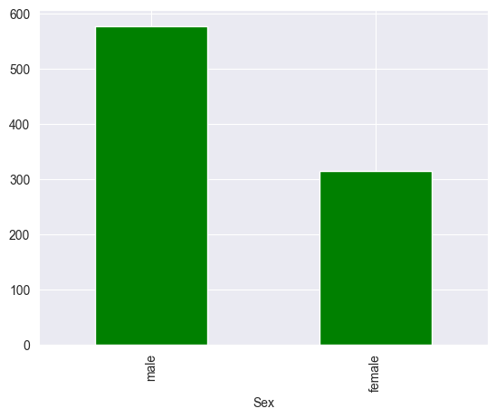

```python
titanic['Sex'].value_counts().plot(kind='bar', color='green');
```

**Observations:**

- call the Series from the dataset, count the unique values, plot
- can be customized when using the .plot(), creating custom graphs

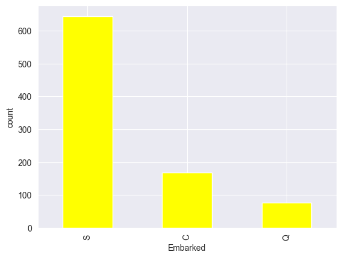

```python
titanic['Embarked'].value_counts().plot(kind='bar', color='yellow')
plt.ylabel('count')
```

**Observations:**

- most of the passengers in this dataset boarded Titanic from the Southamton, UK port.
- the least number of passengers boarded in Quenstown, Ireland.
- the rest of the passengers boarded in Cherbourg, France.

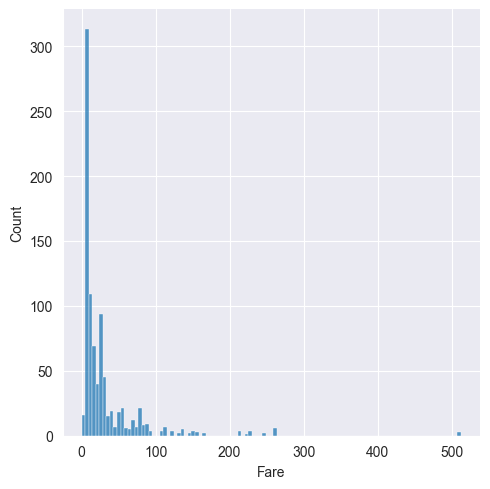

```python
sns.displot(titanic['Fare']);
```

**Observations:**

- displot is a way to see how values are spread out across a dataset
- lets you split your data into groups with different colors to compare them

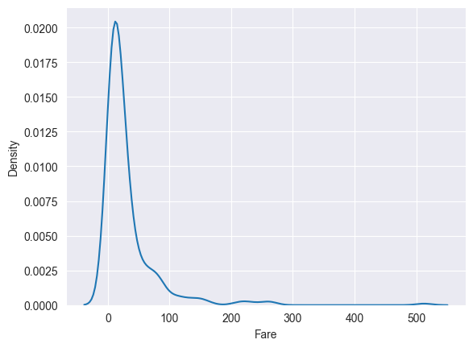

```python
sns.kdeplot(titanic['Fare'])
```

**Observations:**

- KDE (Kernel Density Estimate) curve
- smooth curve that represents the distribution of dat, making it easier to see patterns or trends

#### Bivariate

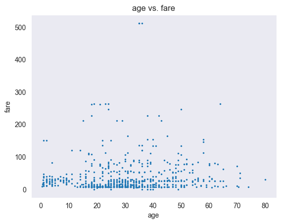

```python
# using a scatter plot to compare age and fare
plt.scatter(titanic['Age'], titanic['Fare'], s=2)
plt.xlabel('age')
plt.ylabel('fare')
plt.title('age vs. fare')
plt.grid();
```

**Observations:**

- scatter plots are used for visualizing the relationship between 2 variables
- can reveal clusters indicating similar characteristics

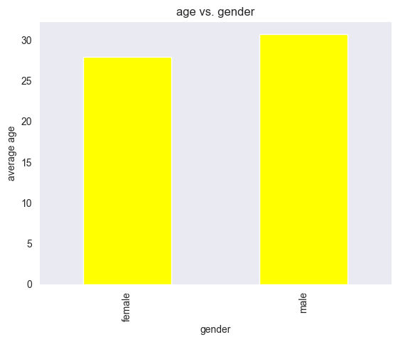

```python
# using a scatter plot to compare age and fare
titanic.groupby('Sex')['Age'].mean().plot(kind='bar', color='yellow')
plt.xlabel('gender')
plt.ylabel('average age')
plt.title('age vs. gender')
plt.grid();
```

**Observations:**

- using groupby one is categorical () and one is numerical []
- best to find mean when there is a lot of data

#### End of Part 2

# Lab 07 - Part 3

#### Bivariate Continued

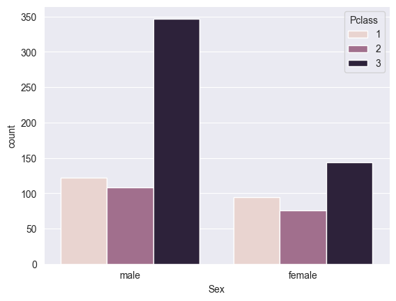

```python
# let's compare sex and pclass variables
sns.countplot(x='Sex', hue='Pclass', data=titanic);
```

**Observations:**

- 'hue' is used to visualize the data of different categories in one plot
- count plots are ideal for categorical data, showing how often each category appears
- make it easy to compare the number of occurences between diferent categories

```python
titanic['Pclass'].value_counts()
```

```
Pclass
3    491
1    216
2    184
Name: count, dtype: int64
```

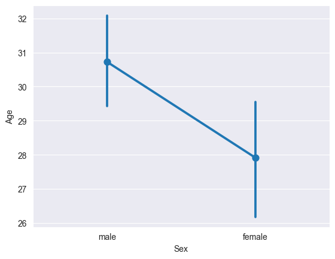

```python
sns.pointplot(x='Sex', y='Age', data=titanic);
#observation:
```

**Observations:**

- shows trends or changes across categories
- the vertical lines (error bars) represent the confidence intervals

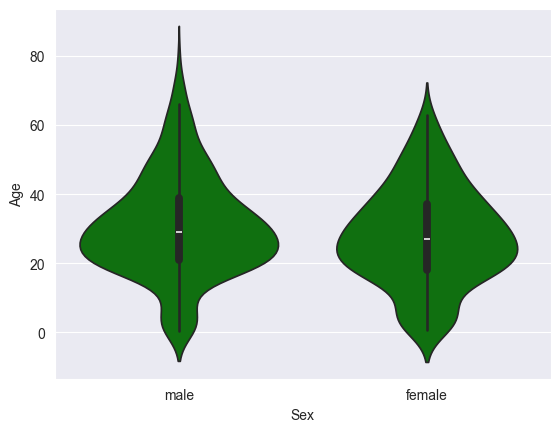

```python
sns.violinplot(x='Sex', y='Age', data=titanic, color='green');
```

**Observations:**

- violin plots combine features of box plots and density plots, showing the summary stats (median) and the distributions of the data across different values
- useful for comparing the distribution of a numeric variable across different categories

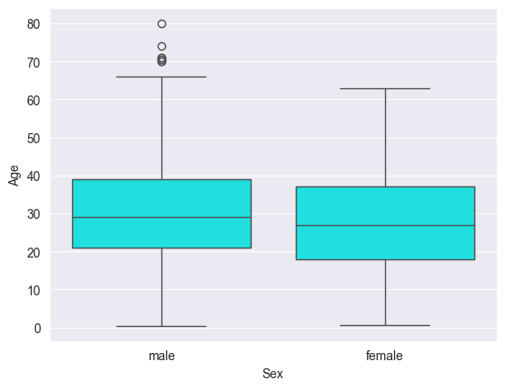

```python
sns.boxplot(x='Sex', y='Age', data=titanic, color='cyan');
```

**Observations:**

- summarize the key statistics of a dataset
- help identify outliers in the data

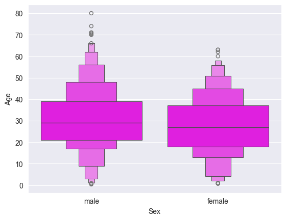

```python
sns.boxenplot(x='Sex', y='Age', data=titanic, color='magenta');
```

**Observations:**

- provide a more detailed view over box plots by dividing the data into more quartiles
- designed to better handle and display outliers

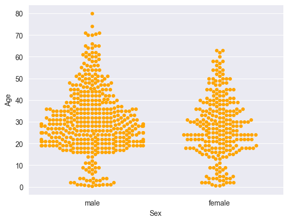

```python
sns.swarmplot(x='Sex', y='Age', data=titanic, color='orange');
```

**Observations:**

- better than a scatter plot as it adjusts the positions of points along the categorical axis to prevent overlapping
- provides insights into both the distribution of values and the individual data points within each category

#### Multivariate Visualization

- comparing more than two variables
- there are three popular multivariate plots:
  1. pairplot()
  2. corr() for correlation between the variables (positive and negative correlation)
  3. heatmap() shows correlation as well

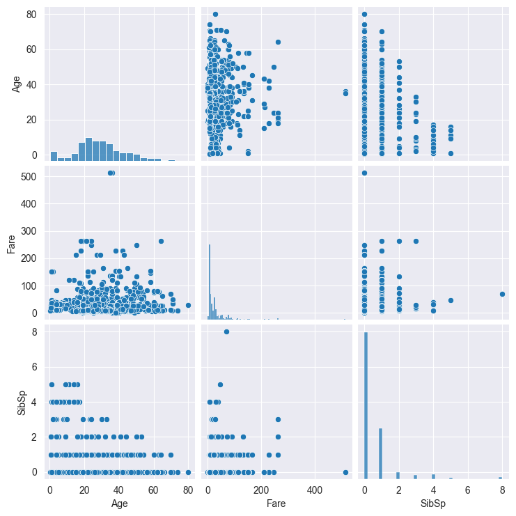

```python
# 1. let's create a pairplot for numeric variables only
sns.pairplot(titanic, vars=['Age', 'Fare', 'SibSp']);
```

**Observations:**

- quickly see how each variable is a dataset relates to other variables
- helps in understanding the individual distributino and the relationships simultaniously

#### Correlation:

1. what is correlation? a relationship
2. what are the types of correlation? positive (when all move in the same direction) or negative (when things move independent of each other [spending/saving])
3. which plot is most popular in presenting correlation? heatmap

```python
#1. first let's create a df that contains only numeric variables
num_vars = titanic[['Fare', 'Age', 'SibSp', 'Parch', 'Survived', 'Pclass']]
num_vars
```

|  | Fare | Age | SibSp | Parch | Survived | Pclass |
| --- | --- | --- | --- | --- | --- | --- |
| 0 | 7.2500 | 22.0 | 1 | 0 | 0 | 3 |
| 1 | 71.2833 | 38.0 | 1 | 0 | 1 | 1 |
| 2 | 7.9250 | 26.0 | 0 | 0 | 1 | 3 |
| 3 | 53.1000 | 35.0 | 1 | 0 | 1 | 1 |
| 4 | 8.0500 | 35.0 | 0 | 0 | 0 | 3 |
| ... | ... | ... | ... | ... | ... | ... |
| 886 | 13.0000 | 27.0 | 0 | 0 | 0 | 2 |
| 887 | 30.0000 | 19.0 | 0 | 0 | 1 | 1 |
| 888 | 23.4500 | NaN | 1 | 2 | 0 | 3 |
| 889 | 30.0000 | 26.0 | 0 | 0 | 1 | 1 |
| 890 | 7.7500 | 32.0 | 0 | 0 | 0 | 3 |

891 rows × 6 columns

```python
#2. let's get the correlation table
num_vars.corr()
```

|  | Fare | Age | SibSp | Parch | Survived | Pclass |
| --- | --- | --- | --- | --- | --- | --- |
| Fare | 1.000000 | 0.096067 | 0.159651 | 0.216225 | 0.257307 | -0.549500 |
| Age | 0.096067 | 1.000000 | -0.308247 | -0.189119 | -0.077221 | -0.369226 |
| SibSp | 0.159651 | -0.308247 | 1.000000 | 0.414838 | -0.035322 | 0.083081 |
| Parch | 0.216225 | -0.189119 | 0.414838 | 1.000000 | 0.081629 | 0.018443 |
| Survived | 0.257307 | -0.077221 | -0.035322 | 0.081629 | 1.000000 | -0.338481 |
| Pclass | -0.549500 | -0.369226 | 0.083081 | 0.018443 | -0.338481 | 1.000000 |

**Observations:**

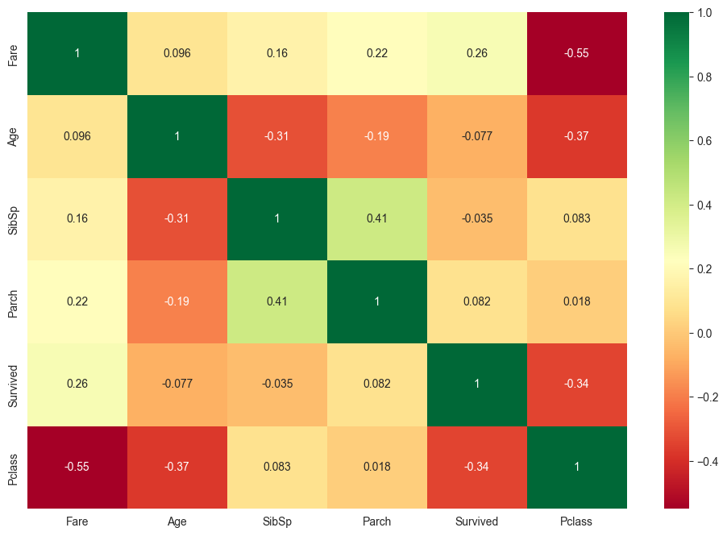

```python
# heatmap: the most popular plot in showing correlation

# setting the size of the plot with pyplot
plt.figure(figsize=(12, 8))

# from seaborn create the heatmap
sns.heatmap(num_vars.corr(), cmap='RdYlGn', annot=True);
```

**Observations:**

- uses color to represent values in a matrix format, making it easy to identify patterns, correlations, and anomalies
- quickly spot which variable are positvely or negatively correlated

**Conclusions:**

- Techniques like box plots, violin plots, and histograms effectively summarize data distributions and key statistics, making it easier to understand large datasets at a glance.
- Count plots, point plots, and swarm plots are particularly useful for comparing frequencies and distributions across different categories, highlighting trends and variations.
- Violin plots and boxen plots provide enhanced clarity in visualizing data distributions, especially in datasets with many outliers or multimodal distributions.
- Scatter plots, pair plots, and point plots are excellent for visualizing relationships between variables, allowing users to identify correlations and potential patterns.
- KDE and swarm plots focus on visualizing the density of data points, helping to understand how values are spread out and the presence of clusters or outliers.
- Heatmaps utilize color gradients to represent data values, facilitating quick identification of patterns and correlations within complex datasets.
- Swarm plots and violin plots allow for the visualization of individual data points alongside distribution patterns, providing deeper insights into the data.
- Pair plots enable simultaneous exploration of relationships between multiple variables, helping to uncover potential correlations that might not be evident from single-variable analysis.
- Box plots and heatmaps provide not only visual insights but also statistical summaries that can inform decision-making and further analysis.
- Overall, these visualization techniques enhance the accessibility of data analysis, making it easier for users to interpret complex information and derive meaningful insights.

#### End of Lab 07